# Clustering

Pedro Antonio Benito Rojano

2022-06-10

# Clustering

## Libraries

Library for R Markdown.

```r
library(rmarkdown)
```

Library for clustering

```r
library(factoextra)
```

Library for data frames processing.

```r
library(dplyr)
```

Library for read dataset.

```r
library(readr)
```

Library for data presentation.

```r
library(scales)
```

Library for manage strings.

```r
library(stringr)
```

## Configuration

### Seed

Set seed.

```r
set.seed(0)
```

### Paths

Set paths.

```r
path_import <- "data/preprocessed.csv"
path_export <- "data/clustering.csv"
```

## Load dataset

```r
virusTotal <- read_csv(path_import)
```

## Preprocessing

### View dataset

```r
virusTotal %>% paged_table()
```

| ...1 | n | size | community_reputation | harmless_votes | malicious_votes | positives | scans.Fortinet.result | submission.filename | submission.submitter_country | submission.submitter_region | times_submitted | total | total_PERMs | unique_sources | additional_info.androguard.AndroidApplication | additional_info.androguard.AndroidVersionCode | additional_info.androguard.AndroidVersionName | additional_info.androguard.certificate.Subject.C | additional_info.androguard.certificate.Subject.CN | additional_info.androguard.certificate.Subject.email | additional_info.androguard.certificate.Subject.L | additional_info.androguard.certificate.Subject.O | additional_info.androguard.certificate.Subject.OU | additional_info.androguard.certificate.Subject.ST | additional_info.androguard.MinSdkVersion | additional_info.androguard.RiskIndicator.APK.SHARED.LIBRARIES | additional_info.androguard.RiskIndicator.PERM.APPOP | additional_info.androguard.RiskIndicator.PERM.DANGEROUS | additional_info.androguard.RiskIndicator.PERM.DEVELOPMENT | … |
| --- | --- | --- | --- | --- | --- | --- | --- | --- | --- | --- | --- | --- | --- | --- | --- | --- | --- | --- | --- | --- | --- | --- | --- | --- | --- | --- | --- | --- | --- | --- |
| 1 | 1 | 1956125 | 0 | 0 | 0 | 20 | Android/Agent.HVN!tr | /vdepot/apk/42/29/42290A1DDB41166F7E8C7536B409F4E6 | US | ca | 1 | 61 | 6 | 1 | 1 | 101 | 23.5.3 | NA | NA | NA | NA | NA | NA | FI | 16 | 0 | 0 | 2 | 0 | … |
| 2 | 2 | 2667641 | 0 | 0 | 0 | 20 | Android/Erwind.A!tr | 398e6e8146d61470c4699f28f168188d.virus | CA | on | 1 | 61 | 10 | 1 | 1 | 9 | 0.8.6 | NL | Jina Gasilov | android@android.com | You Bet | Vandervort-D'Amore | Android | California | 14 | 0 | 0 | 4 | 0 | … |
| 3 | 3 | 3998656 | 0 | 0 | 0 | 18 | Android/Agent.IMA!tr | 07d00b70d7f6.zip | UA | 63 | 1 | 61 | 22 | 1 | 1 | 1 | 1.5 | US | Android | android@android.com | Mountain View | Android | Android | California | 24 | 0 | 0 | 1 | 0 | … |
| 4 | 4 | 500276 | -34 | 18 | 13 | 26 | Android/Generic.S.64F1!tr | WiFiKill-me.paranoid.wifikill-2032-v2.3.2.apk | IE | d | 263 | 64 | 4 | 514 | 1 | 2032 | 2.3.2 | NA | MessyBinary | NA | NA | NA | NA | NA | 14 | 3 | 0 | 0 | 0 | … |
| 5 | 5 | 1956125 | 0 | 0 | 0 | 20 | Android/Agent.HVN!tr | /vdepot/apk/CD/74/CD74C3D8DE98A8F238BB9D6735380404 | US | ca | 1 | 62 | 6 | 1 | 1 | 101 | 23.5.3 | NA | NA | NA | NA | NA | NA | FI | 16 | 0 | 0 | 2 | 0 | … |
| 6 | 6 | 4137920 | 0 | 0 | 0 | 18 | Android/Agent.IVA!tr | ff6f1dd413e4.zip | UA | 63 | 1 | 61 | 22 | 1 | 1 | 1 | 1.5 | US | Android | android@android.com | Mountain View | Android | Android | California | 24 | 0 | 0 | 1 | 0 | … |
| 7 | 7 | 3031864 | 0 | 0 | 0 | 15 | Riskware/Generic.Z.1114DCE!Android | b8456ae6435a76bc7713734f7d273a50.virobj | UA | 30 | 2 | 61 | 0 | 2 | 0 | NA | NA | NA | NA | NA | NA | NA | NA | NA | NA | 0 | 0 | 0 | 0 | … |
| 8 | 8 | 2669106 | 0 | 0 | 0 | 20 | Android/Erwind.A!tr | 511a4359f936ffc8419ff53c97a1af2c.virus | CA | on | 1 | 60 | 10 | 1 | 1 | 9 | 0.8.6 | NL | Jina Gasilov | android@android.com | You Bet | Vandervort-D'Amore | Android | California | 14 | 0 | 0 | 4 | 0 | … |
| 9 | 9 | 2669106 | 0 | 0 | 0 | 21 | Android/Erwind.A!tr | ed89d9884a455e4d9534785edbfe4824.virus | CA | on | 1 | 60 | 10 | 1 | 1 | 9 | 0.8.6 | NL | Jina Gasilov | android@android.com | You Bet | Vandervort-D'Amore | Android | California | 14 | 0 | 0 | 4 | 0 | … |
| 10 | 10 | 5884 | 0 | 0 | 0 | 25 | Android/Shedun.AC!tr | /home/farm/anteroom/0b9/111/0b911143341c6fd040b785df145f64b6a0a3751d55acb0c990f6c326ae7690fa | CZ | jm | 4 | 60 | 0 | 2 | 2 | NA | NA | NA | NA | NA | NA | NA | NA | NA | NA | 0 | 0 | 0 | 0 | … |

[output cut: 173 more lines]

### Remove row number columns

As can be seen, at read the col …1 is added, but the column n already has this information.

Both of them are not interesting columns for clustering, so remove them.

```r
df <-
  virusTotal %>%
  select(-...1, -n)
```

### Cast logical columns as numeric

Cast logical to numeric in order to be able to cluster with them.

```r
df <-
  df %>%
  mutate_if(is.logical, as.numeric)
```

### Select numeric columns

Only numeric columns are suitable for clustering, so just remove them.

```r
df <-
  df %>%
  select_if(is.numeric)
```

### Rows with NA

```r
rows_with_na <-
  function(df){
      df %>%
      is.na() %>%
      rowSums() %>%
      sapply(function(x) x > 0) %>%
      which()
  }
```

```r
nrows_with_na <-
  df %>%
  rows_with_na() %>%
  length()

nrows_with_na / nrow(df)
```

```
## [1] 0.863388
```

Most of the rows of the dataframe has NA so can’t be deleted. If rows with NA were deleted most of the information will be loss.

### Replace NA

Clustering do not work with NAs because distance measure is needed. So just replace NA for predicted value using lineal model.

```r
remove_0 <-
  function(x) x[x!=0]
```

```r
num_of_NA_by_column <-
  function(df){
    df %>% is.na() %>% colSums()
  }
```

```r
names_of_colums_with_NA <-
  function(df)
    df %>%
      num_of_NA_by_column() %>%
      remove_0 %>%
      names()
```

```r
lm_from_all_columns <-
  function(df, column){
    target_column_name <-
      colnames(df)[column]
    col <- df[,column]
    df <-
      df %>%
      select(., -all_of(names_of_colums_with_NA(.))) %>%
      cbind(col)
    formula_lm <-
      paste(target_column_name, ".", sep = " ~ ") %>%
      as.formula()
    lm(formula_lm, data = df, na.action = na.omit)
  }
```

```r
replace_NA_by_predicted_col <-
  function(df, col_index){
    col <-
      df[, col_index] %>%
      unlist()
    has_na <-
      col %>%
      anyNA()
    if(has_na){
      lm_col <-
        lm_from_all_columns(df, col_index)
      col_predicted <-
        predict.lm(lm_col, df) %>%
        as.double()
      na_col <-
        col %>%
        sapply(is.na) %>%
        as.vector()
      col <-
        if_else(na_col, col_predicted, col)
    }
    col <-
      as.vector(col)
    return(col)
  }
```

```r
replace_NA_by_predicted <-
  function(df){
    for(index in 1:ncol(df)){
      df[,index] <- replace_NA_by_predicted_col(df, index)
    }
    return(df)
  }
```

```r
df <-
  replace_NA_by_predicted(df)
```

### View result

```r
df %>%
  paged_table()
```

| size | community_reputation | harmless_votes | malicious_votes | positives | times_submitted | total | total_PERMs | unique_sources | additional_info.androguard.AndroidApplication | additional_info.androguard.AndroidVersionCode | additional_info.androguard.MinSdkVersion | additional_info.androguard.RiskIndicator.APK.SHARED.LIBRARIES | additional_info.androguard.RiskIndicator.PERM.APPOP | additional_info.androguard.RiskIndicator.PERM.DANGEROUS | additional_info.androguard.RiskIndicator.PERM.DEVELOPMENT | additional_info.androguard.RiskIndicator.PERM.EPHEMERAL | additional_info.androguard.RiskIndicator.PERM.GPS | additional_info.androguard.RiskIndicator.PERM.INSTANT | additional_info.androguard.RiskIndicator.PERM.MONEY | additional_info.androguard.RiskIndicator.PERM.NORMAL | additional_info.androguard.RiskIndicator.PERM.PRE23 | additional_info.androguard.RiskIndicator.PERM.PREINSTALLED | additional_info.androguard.RiskIndicator.PERM.PRIVACY | additional_info.androguard.RiskIndicator.PERM.SIGNATURE | additional_info.androguard.RiskIndicator.PERM.SMS | additional_info.androguard.RiskIndicator.PERM.SYSTEM | additional_info.androguard.TargetSdkVersion | additional_info.compressedview.file_types.DEX | additional_info.compressedview.file_types.ELF | … |
| --- | --- | --- | --- | --- | --- | --- | --- | --- | --- | --- | --- | --- | --- | --- | --- | --- | --- | --- | --- | --- | --- | --- | --- | --- | --- | --- | --- | --- | --- | --- |
| 1956125 | 0 | 0 | 0 | 20 | 1 | 61 | 6 | 1 | 1 | 1.010000e+02 | 16.00000 | 0 | 0 | 2 | 0 | 0 | 1 | 0 | 0 | 2 | 0 | 0 | 1 | 0 | 0 | 0 | 2.200000e+01 | 1 | 0 | … |
| 2667641 | 0 | 0 | 0 | 20 | 1 | 61 | 10 | 1 | 1 | 9.000000e+00 | 14.00000 | 0 | 0 | 4 | 0 | 0 | 0 | 0 | 0 | 5 | 0 | 0 | 1 | 0 | 0 | 0 | 2.200000e+01 | 3 | 0 | … |
| 3998656 | 0 | 0 | 0 | 18 | 1 | 61 | 22 | 1 | 1 | 1.000000e+00 | 24.00000 | 0 | 0 | 1 | 0 | 0 | 0 | 4 | 2 | 7 | 0 | 0 | 4 | 0 | 4 | 0 | 2.800000e+01 | 0 | 0 | … |
| 500276 | -34 | 18 | 13 | 26 | 263 | 64 | 4 | 514 | 1 | 2.032000e+03 | 14.00000 | 3 | 0 | 0 | 0 | 0 | 0 | 0 | 0 | 4 | 0 | 0 | 0 | 0 | 0 | 0 | 1.700000e+01 | 1 | 3 | … |
| 1956125 | 0 | 0 | 0 | 20 | 1 | 62 | 6 | 1 | 1 | 1.010000e+02 | 16.00000 | 0 | 0 | 2 | 0 | 0 | 1 | 0 | 0 | 2 | 0 | 0 | 1 | 0 | 0 | 0 | 2.200000e+01 | 1 | 0 | … |
| 4137920 | 0 | 0 | 0 | 18 | 1 | 61 | 22 | 1 | 1 | 1.000000e+00 | 24.00000 | 0 | 0 | 1 | 0 | 0 | 0 | 4 | 2 | 7 | 0 | 0 | 4 | 0 | 4 | 0 | 2.800000e+01 | 0 | 0 | … |
| 3031864 | 0 | 0 | 0 | 15 | 2 | 61 | 0 | 2 | 0 | 8.198732e+02 | 20.73393 | 0 | 0 | 0 | 0 | 0 | 0 | 0 | 0 | 0 | 0 | 0 | 0 | 0 | 0 | 0 | 1.842469e+01 | 0 | 0 | … |
| 2669106 | 0 | 0 | 0 | 20 | 1 | 60 | 10 | 1 | 1 | 9.000000e+00 | 14.00000 | 0 | 0 | 4 | 0 | 0 | 0 | 0 | 0 | 5 | 0 | 0 | 1 | 0 | 0 | 0 | 2.200000e+01 | 3 | 0 | … |
| 2669106 | 0 | 0 | 0 | 21 | 1 | 60 | 10 | 1 | 1 | 9.000000e+00 | 14.00000 | 0 | 0 | 4 | 0 | 0 | 0 | 0 | 0 | 5 | 0 | 0 | 1 | 0 | 0 | 0 | 2.200000e+01 | 3 | 0 | … |
| 5884 | 0 | 0 | 0 | 25 | 4 | 60 | 0 | 2 | 2 | -8.846018e+05 | 350.97734 | 0 | 0 | 0 | 0 | 0 | 0 | 0 | 0 | 0 | 0 | 0 | 0 | 0 | 0 | 0 | 4.622255e+02 | 0 | 0 | … |

[output cut: 173 more lines]

## Clustering

### K-Means

#### Optimal number of clusters

Plot a graphic about the optimal number of clusters.

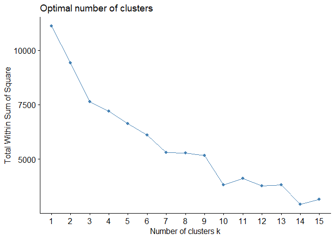

```r
df %>%
  scale() %>%
  fviz_nbclust(kmeans, method = "wss", k.max = 15)
```

As can be seen 3, 7 and 10 clusters seem to be optimal number of clusters.

#### Define a function

```r
cluster_k <- function(df, k){
  df_scale <-
    df %>%
    scale() %>%
    as.data.frame()
  l <- list()
  l$kmeans <-
    kmeans(df_scale, centers = k, nstart = 25)
  l$plot <-
    l$kmeans %>%
    fviz_cluster(geom = "point", data = df_scale) +
    ggtitle(paste("k", k, sep="="))
  l$table <- tibble(row = 1:nrow(df), cluster = l$kmeans$cluster, df)
  l$cluster_size <-
    l$table %>%
    group_by(cluster) %>%
    summarise(size=n())
  return(l)
}
```

#### K-3

Apply kmeans with 3 clusters.

```r
cluster_k3 <-
  cluster_k(df, 3)
```

Show results

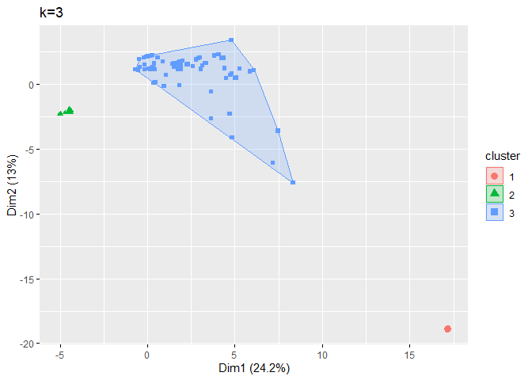

```r
cluster_k3$plot
```

```r
cluster_k3$table %>%
  paged_table()
```

| row | cluster | size | community_reputation | harmless_votes | malicious_votes | positives | times_submitted | total | total_PERMs | unique_sources | additional_info.androguard.AndroidApplication | additional_info.androguard.AndroidVersionCode | additional_info.androguard.MinSdkVersion | additional_info.androguard.RiskIndicator.APK.SHARED.LIBRARIES | additional_info.androguard.RiskIndicator.PERM.APPOP | additional_info.androguard.RiskIndicator.PERM.DANGEROUS | additional_info.androguard.RiskIndicator.PERM.DEVELOPMENT | additional_info.androguard.RiskIndicator.PERM.EPHEMERAL | additional_info.androguard.RiskIndicator.PERM.GPS | additional_info.androguard.RiskIndicator.PERM.INSTANT | additional_info.androguard.RiskIndicator.PERM.MONEY | additional_info.androguard.RiskIndicator.PERM.NORMAL | additional_info.androguard.RiskIndicator.PERM.PRE23 | additional_info.androguard.RiskIndicator.PERM.PREINSTALLED | additional_info.androguard.RiskIndicator.PERM.PRIVACY | additional_info.androguard.RiskIndicator.PERM.SIGNATURE | additional_info.androguard.RiskIndicator.PERM.SMS | additional_info.androguard.RiskIndicator.PERM.SYSTEM | additional_info.androguard.TargetSdkVersion | … |
| --- | --- | --- | --- | --- | --- | --- | --- | --- | --- | --- | --- | --- | --- | --- | --- | --- | --- | --- | --- | --- | --- | --- | --- | --- | --- | --- | --- | --- | --- | --- |
| 1 | 3 | 1956125 | 0 | 0 | 0 | 20 | 1 | 61 | 6 | 1 | 1 | 1.010000e+02 | 16.00000 | 0 | 0 | 2 | 0 | 0 | 1 | 0 | 0 | 2 | 0 | 0 | 1 | 0 | 0 | 0 | 2.200000e+01 | … |
| 2 | 3 | 2667641 | 0 | 0 | 0 | 20 | 1 | 61 | 10 | 1 | 1 | 9.000000e+00 | 14.00000 | 0 | 0 | 4 | 0 | 0 | 0 | 0 | 0 | 5 | 0 | 0 | 1 | 0 | 0 | 0 | 2.200000e+01 | … |
| 3 | 3 | 3998656 | 0 | 0 | 0 | 18 | 1 | 61 | 22 | 1 | 1 | 1.000000e+00 | 24.00000 | 0 | 0 | 1 | 0 | 0 | 0 | 4 | 2 | 7 | 0 | 0 | 4 | 0 | 4 | 0 | 2.800000e+01 | … |
| 4 | 3 | 500276 | -34 | 18 | 13 | 26 | 263 | 64 | 4 | 514 | 1 | 2.032000e+03 | 14.00000 | 3 | 0 | 0 | 0 | 0 | 0 | 0 | 0 | 4 | 0 | 0 | 0 | 0 | 0 | 0 | 1.700000e+01 | … |
| 5 | 3 | 1956125 | 0 | 0 | 0 | 20 | 1 | 62 | 6 | 1 | 1 | 1.010000e+02 | 16.00000 | 0 | 0 | 2 | 0 | 0 | 1 | 0 | 0 | 2 | 0 | 0 | 1 | 0 | 0 | 0 | 2.200000e+01 | … |
| 6 | 3 | 4137920 | 0 | 0 | 0 | 18 | 1 | 61 | 22 | 1 | 1 | 1.000000e+00 | 24.00000 | 0 | 0 | 1 | 0 | 0 | 0 | 4 | 2 | 7 | 0 | 0 | 4 | 0 | 4 | 0 | 2.800000e+01 | … |
| 7 | 3 | 3031864 | 0 | 0 | 0 | 15 | 2 | 61 | 0 | 2 | 0 | 8.198732e+02 | 20.73393 | 0 | 0 | 0 | 0 | 0 | 0 | 0 | 0 | 0 | 0 | 0 | 0 | 0 | 0 | 0 | 1.842469e+01 | … |
| 8 | 3 | 2669106 | 0 | 0 | 0 | 20 | 1 | 60 | 10 | 1 | 1 | 9.000000e+00 | 14.00000 | 0 | 0 | 4 | 0 | 0 | 0 | 0 | 0 | 5 | 0 | 0 | 1 | 0 | 0 | 0 | 2.200000e+01 | … |
| 9 | 3 | 2669106 | 0 | 0 | 0 | 21 | 1 | 60 | 10 | 1 | 1 | 9.000000e+00 | 14.00000 | 0 | 0 | 4 | 0 | 0 | 0 | 0 | 0 | 5 | 0 | 0 | 1 | 0 | 0 | 0 | 2.200000e+01 | … |
| 10 | 2 | 5884 | 0 | 0 | 0 | 25 | 4 | 60 | 0 | 2 | 2 | -8.846018e+05 | 350.97734 | 0 | 0 | 0 | 0 | 0 | 0 | 0 | 0 | 0 | 0 | 0 | 0 | 0 | 0 | 0 | 4.622255e+02 | … |

[output cut: 173 more lines]

```r
cluster_k3$cluster_size %>%
  paged_table()
```

| cluster | size |
| --- | --- |
| 1 | 2 |
| 2 | 58 |
| 3 | 123 |

#### K-7

Apply kmeans with 7 clusters.

```r
cluster_k7 <-
  cluster_k(df, 7)
```

Show results

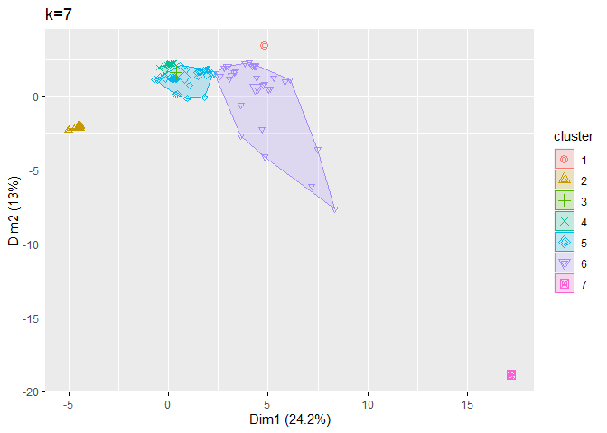

```r
cluster_k7$plot
```

```r
cluster_k7$table %>%
  paged_table()
```

| row | cluster | size | community_reputation | harmless_votes | malicious_votes | positives | times_submitted | total | total_PERMs | unique_sources | additional_info.androguard.AndroidApplication | additional_info.androguard.AndroidVersionCode | additional_info.androguard.MinSdkVersion | additional_info.androguard.RiskIndicator.APK.SHARED.LIBRARIES | additional_info.androguard.RiskIndicator.PERM.APPOP | additional_info.androguard.RiskIndicator.PERM.DANGEROUS | additional_info.androguard.RiskIndicator.PERM.DEVELOPMENT | additional_info.androguard.RiskIndicator.PERM.EPHEMERAL | additional_info.androguard.RiskIndicator.PERM.GPS | additional_info.androguard.RiskIndicator.PERM.INSTANT | additional_info.androguard.RiskIndicator.PERM.MONEY | additional_info.androguard.RiskIndicator.PERM.NORMAL | additional_info.androguard.RiskIndicator.PERM.PRE23 | additional_info.androguard.RiskIndicator.PERM.PREINSTALLED | additional_info.androguard.RiskIndicator.PERM.PRIVACY | additional_info.androguard.RiskIndicator.PERM.SIGNATURE | additional_info.androguard.RiskIndicator.PERM.SMS | additional_info.androguard.RiskIndicator.PERM.SYSTEM | additional_info.androguard.TargetSdkVersion | … |
| --- | --- | --- | --- | --- | --- | --- | --- | --- | --- | --- | --- | --- | --- | --- | --- | --- | --- | --- | --- | --- | --- | --- | --- | --- | --- | --- | --- | --- | --- | --- |
| 1 | 5 | 1956125 | 0 | 0 | 0 | 20 | 1 | 61 | 6 | 1 | 1 | 1.010000e+02 | 16.00000 | 0 | 0 | 2 | 0 | 0 | 1 | 0 | 0 | 2 | 0 | 0 | 1 | 0 | 0 | 0 | 2.200000e+01 | … |
| 2 | 4 | 2667641 | 0 | 0 | 0 | 20 | 1 | 61 | 10 | 1 | 1 | 9.000000e+00 | 14.00000 | 0 | 0 | 4 | 0 | 0 | 0 | 0 | 0 | 5 | 0 | 0 | 1 | 0 | 0 | 0 | 2.200000e+01 | … |
| 3 | 6 | 3998656 | 0 | 0 | 0 | 18 | 1 | 61 | 22 | 1 | 1 | 1.000000e+00 | 24.00000 | 0 | 0 | 1 | 0 | 0 | 0 | 4 | 2 | 7 | 0 | 0 | 4 | 0 | 4 | 0 | 2.800000e+01 | … |
| 4 | 3 | 500276 | -34 | 18 | 13 | 26 | 263 | 64 | 4 | 514 | 1 | 2.032000e+03 | 14.00000 | 3 | 0 | 0 | 0 | 0 | 0 | 0 | 0 | 4 | 0 | 0 | 0 | 0 | 0 | 0 | 1.700000e+01 | … |
| 5 | 5 | 1956125 | 0 | 0 | 0 | 20 | 1 | 62 | 6 | 1 | 1 | 1.010000e+02 | 16.00000 | 0 | 0 | 2 | 0 | 0 | 1 | 0 | 0 | 2 | 0 | 0 | 1 | 0 | 0 | 0 | 2.200000e+01 | … |
| 6 | 6 | 4137920 | 0 | 0 | 0 | 18 | 1 | 61 | 22 | 1 | 1 | 1.000000e+00 | 24.00000 | 0 | 0 | 1 | 0 | 0 | 0 | 4 | 2 | 7 | 0 | 0 | 4 | 0 | 4 | 0 | 2.800000e+01 | … |
| 7 | 5 | 3031864 | 0 | 0 | 0 | 15 | 2 | 61 | 0 | 2 | 0 | 8.198732e+02 | 20.73393 | 0 | 0 | 0 | 0 | 0 | 0 | 0 | 0 | 0 | 0 | 0 | 0 | 0 | 0 | 0 | 1.842469e+01 | … |
| 8 | 4 | 2669106 | 0 | 0 | 0 | 20 | 1 | 60 | 10 | 1 | 1 | 9.000000e+00 | 14.00000 | 0 | 0 | 4 | 0 | 0 | 0 | 0 | 0 | 5 | 0 | 0 | 1 | 0 | 0 | 0 | 2.200000e+01 | … |
| 9 | 4 | 2669106 | 0 | 0 | 0 | 21 | 1 | 60 | 10 | 1 | 1 | 9.000000e+00 | 14.00000 | 0 | 0 | 4 | 0 | 0 | 0 | 0 | 0 | 5 | 0 | 0 | 1 | 0 | 0 | 0 | 2.200000e+01 | … |
| 10 | 2 | 5884 | 0 | 0 | 0 | 25 | 4 | 60 | 0 | 2 | 2 | -8.846018e+05 | 350.97734 | 0 | 0 | 0 | 0 | 0 | 0 | 0 | 0 | 0 | 0 | 0 | 0 | 0 | 0 | 0 | 4.622255e+02 | … |

[output cut: 173 more lines]

```r
cluster_k7$cluster_size %>%
  paged_table()
```

| cluster | size |
| --- | --- |
| 1 | 1 |
| 2 | 58 |
| 3 | 1 |
| 4 | 32 |
| 5 | 48 |
| 6 | 41 |
| 7 | 2 |

Again in k-7 clusters there are four main groups but the others has only 1 or 2 viruses.

That is so curious.

#### K-10

Apply kmeans with 10 clusters.

```r
cluster_k10 <-
  cluster_k(df, 10)
```

Show results

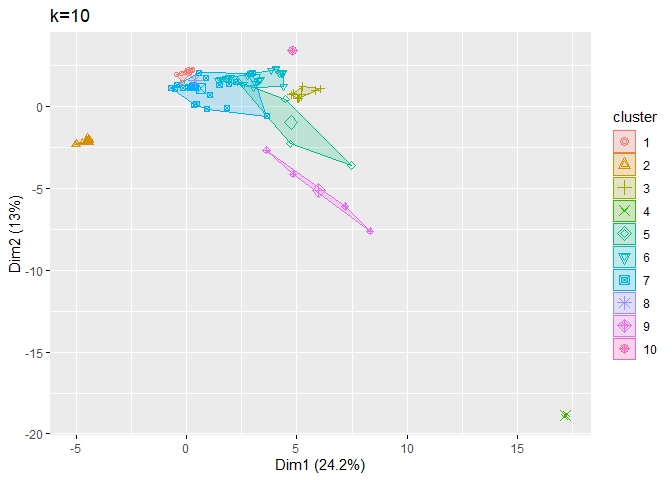

```r
cluster_k10$plot
```

```r
cluster_k10$table %>%
  paged_table()
```

| row | cluster | size | community_reputation | harmless_votes | malicious_votes | positives | times_submitted | total | total_PERMs | unique_sources | additional_info.androguard.AndroidApplication | additional_info.androguard.AndroidVersionCode | additional_info.androguard.MinSdkVersion | additional_info.androguard.RiskIndicator.APK.SHARED.LIBRARIES | additional_info.androguard.RiskIndicator.PERM.APPOP | additional_info.androguard.RiskIndicator.PERM.DANGEROUS | additional_info.androguard.RiskIndicator.PERM.DEVELOPMENT | additional_info.androguard.RiskIndicator.PERM.EPHEMERAL | additional_info.androguard.RiskIndicator.PERM.GPS | additional_info.androguard.RiskIndicator.PERM.INSTANT | additional_info.androguard.RiskIndicator.PERM.MONEY | additional_info.androguard.RiskIndicator.PERM.NORMAL | additional_info.androguard.RiskIndicator.PERM.PRE23 | additional_info.androguard.RiskIndicator.PERM.PREINSTALLED | additional_info.androguard.RiskIndicator.PERM.PRIVACY | additional_info.androguard.RiskIndicator.PERM.SIGNATURE | additional_info.androguard.RiskIndicator.PERM.SMS | additional_info.androguard.RiskIndicator.PERM.SYSTEM | additional_info.androguard.TargetSdkVersion | … |
| --- | --- | --- | --- | --- | --- | --- | --- | --- | --- | --- | --- | --- | --- | --- | --- | --- | --- | --- | --- | --- | --- | --- | --- | --- | --- | --- | --- | --- | --- | --- |
| 1 | 7 | 1956125 | 0 | 0 | 0 | 20 | 1 | 61 | 6 | 1 | 1 | 1.010000e+02 | 16.00000 | 0 | 0 | 2 | 0 | 0 | 1 | 0 | 0 | 2 | 0 | 0 | 1 | 0 | 0 | 0 | 2.200000e+01 | … |
| 2 | 1 | 2667641 | 0 | 0 | 0 | 20 | 1 | 61 | 10 | 1 | 1 | 9.000000e+00 | 14.00000 | 0 | 0 | 4 | 0 | 0 | 0 | 0 | 0 | 5 | 0 | 0 | 1 | 0 | 0 | 0 | 2.200000e+01 | … |
| 3 | 6 | 3998656 | 0 | 0 | 0 | 18 | 1 | 61 | 22 | 1 | 1 | 1.000000e+00 | 24.00000 | 0 | 0 | 1 | 0 | 0 | 0 | 4 | 2 | 7 | 0 | 0 | 4 | 0 | 4 | 0 | 2.800000e+01 | … |
| 4 | 8 | 500276 | -34 | 18 | 13 | 26 | 263 | 64 | 4 | 514 | 1 | 2.032000e+03 | 14.00000 | 3 | 0 | 0 | 0 | 0 | 0 | 0 | 0 | 4 | 0 | 0 | 0 | 0 | 0 | 0 | 1.700000e+01 | … |
| 5 | 7 | 1956125 | 0 | 0 | 0 | 20 | 1 | 62 | 6 | 1 | 1 | 1.010000e+02 | 16.00000 | 0 | 0 | 2 | 0 | 0 | 1 | 0 | 0 | 2 | 0 | 0 | 1 | 0 | 0 | 0 | 2.200000e+01 | … |
| 6 | 6 | 4137920 | 0 | 0 | 0 | 18 | 1 | 61 | 22 | 1 | 1 | 1.000000e+00 | 24.00000 | 0 | 0 | 1 | 0 | 0 | 0 | 4 | 2 | 7 | 0 | 0 | 4 | 0 | 4 | 0 | 2.800000e+01 | … |
| 7 | 7 | 3031864 | 0 | 0 | 0 | 15 | 2 | 61 | 0 | 2 | 0 | 8.198732e+02 | 20.73393 | 0 | 0 | 0 | 0 | 0 | 0 | 0 | 0 | 0 | 0 | 0 | 0 | 0 | 0 | 0 | 1.842469e+01 | … |
| 8 | 1 | 2669106 | 0 | 0 | 0 | 20 | 1 | 60 | 10 | 1 | 1 | 9.000000e+00 | 14.00000 | 0 | 0 | 4 | 0 | 0 | 0 | 0 | 0 | 5 | 0 | 0 | 1 | 0 | 0 | 0 | 2.200000e+01 | … |
| 9 | 1 | 2669106 | 0 | 0 | 0 | 21 | 1 | 60 | 10 | 1 | 1 | 9.000000e+00 | 14.00000 | 0 | 0 | 4 | 0 | 0 | 0 | 0 | 0 | 5 | 0 | 0 | 1 | 0 | 0 | 0 | 2.200000e+01 | … |
| 10 | 2 | 5884 | 0 | 0 | 0 | 25 | 4 | 60 | 0 | 2 | 2 | -8.846018e+05 | 350.97734 | 0 | 0 | 0 | 0 | 0 | 0 | 0 | 0 | 0 | 0 | 0 | 0 | 0 | 0 | 0 | 4.622255e+02 | … |

[output cut: 173 more lines]

```r
cluster_k10$cluster_size %>%
  paged_table()
```

| cluster | size |
| --- | --- |
| 1 | 32 |
| 2 | 58 |
| 3 | 9 |
| 4 | 2 |
| 5 | 4 |
| 6 | 33 |
| 7 | 39 |
| 8 | 1 |
| 9 | 4 |
| 10 | 1 |

Again in k-10 clusters there are many small groups that are very different from the rest in terms of number of viruses clasified in.

#### Conclusion

This is so strange clustering distribution, so would be interesting to inspect why it is happening.

#### Add cluster information to the dataframe.

```r
df_clustering_info_added <-
  df %>%
  mutate(
    analysis_info.clustering.cluster.k3 =
      cluster_k3$kmeans$cluster) %>%
  mutate(
    analysis_info.clustering.cluster.k7 =
      cluster_k7$kmeans$cluster) %>%
  mutate(
    analysis_info.clustering.cluster.k10 =
      cluster_k10$kmeans$cluster)
```

### Inspect small groups

Define a function.

```r
small_clusters <-
  function(table_cluster_size, percent){
    max <-
      max(table_cluster_size$size)
    min <-
      min(table_cluster_size$size)
    threshold <-
      min + (max - min) * percent
    small_clusters <-
      table_cluster_size %>%
      filter(size <= threshold) %>%
      select(cluster) %>%
      unlist()
    return(small_clusters)
  }
```

```r
belongs_to_small_cluster <-
  function(cluster, small_clusters)
    cluster %in% small_clusters
```

#### Small clusters of k10

Compute small clusters of k10

```r
small_clusters_k10 <-
  cluster_k10$cluster_size %>%
  small_clusters(0.2)
```

Show rows that belong to small clusters.

```r
belongs_to_small_cluster_k10 <-
  belongs_to_small_cluster(
    cluster_k10$table$cluster,
    small_clusters_k10
  )

small_groups_df <-
  df %>%
  filter(belongs_to_small_cluster_k10)
small_groups_df %>%
  paged_table()
```

| size | community_reputation | harmless_votes | malicious_votes | positives | times_submitted | total | total_PERMs | unique_sources | additional_info.androguard.AndroidApplication | additional_info.androguard.AndroidVersionCode | additional_info.androguard.MinSdkVersion | additional_info.androguard.RiskIndicator.APK.SHARED.LIBRARIES | additional_info.androguard.RiskIndicator.PERM.APPOP | additional_info.androguard.RiskIndicator.PERM.DANGEROUS | additional_info.androguard.RiskIndicator.PERM.DEVELOPMENT | additional_info.androguard.RiskIndicator.PERM.EPHEMERAL | additional_info.androguard.RiskIndicator.PERM.GPS | additional_info.androguard.RiskIndicator.PERM.INSTANT | additional_info.androguard.RiskIndicator.PERM.MONEY | additional_info.androguard.RiskIndicator.PERM.NORMAL | additional_info.androguard.RiskIndicator.PERM.PRE23 | additional_info.androguard.RiskIndicator.PERM.PREINSTALLED | additional_info.androguard.RiskIndicator.PERM.PRIVACY | additional_info.androguard.RiskIndicator.PERM.SIGNATURE | additional_info.androguard.RiskIndicator.PERM.SMS | additional_info.androguard.RiskIndicator.PERM.SYSTEM | additional_info.androguard.TargetSdkVersion | additional_info.compressedview.file_types.DEX | additional_info.compressedview.file_types.ELF | … |
| --- | --- | --- | --- | --- | --- | --- | --- | --- | --- | --- | --- | --- | --- | --- | --- | --- | --- | --- | --- | --- | --- | --- | --- | --- | --- | --- | --- | --- | --- | --- |
| 500276 | -34 | 18 | 13 | 26 | 263 | 64 | 4 | 514 | 1 | 2032 | 14 | 3 | 0 | 0 | 0 | 0 | 0 | 0 | 0 | 4 | 0 | 0 | 0 | 0 | 0 | 0 | 17 | 1 | 3 | … |
| 15202016 | 0 | 0 | 0 | 17 | 1 | 63 | 34 | 1 | 1 | 41 | 19 | 10 | 0 | 8 | 0 | 0 | 3 | 0 | 1 | 10 | 0 | 0 | 8 | 1 | 2 | 1 | 22 | 1 | 10 | … |
| 20353542 | 0 | 0 | 0 | 22 | 1 | 63 | 58 | 1 | 1 | 2017011016 | 16 | 12 | 3 | 5 | 2 | 3 | 3 | 0 | 2 | 14 | 2 | 2 | 9 | 8 | 2 | 3 | 26 | 2 | 37 | … |
| 30711904 | 0 | 0 | 0 | 18 | 1 | 61 | 20 | 1 | 1 | 6 | 21 | 5 | 0 | 2 | 0 | 0 | 3 | 2 | 0 | 6 | 0 | 0 | 7 | 0 | 0 | 0 | 28 | 5 | 16 | … |
| 3903113 | -58 | 0 | 1 | 37 | 2 | 64 | 39 | 2 | 1 | 2000001 | 21 | 1 | 3 | 3 | 2 | 2 | 0 | 0 | 2 | 8 | 1 | 1 | 6 | 5 | 5 | 1 | 26 | 1 | 1 | … |
| 543672 | 0 | 0 | 0 | 24 | 1 | 62 | 24 | 1 | 1 | 60 | 21 | 0 | 2 | 2 | 1 | 0 | 2 | 4 | 0 | 7 | 1 | 1 | 2 | 2 | 0 | 0 | 28 | 1 | 0 | … |
| 15721098 | 0 | 0 | 0 | 16 | 1 | 60 | 34 | 1 | 1 | 41 | 19 | 10 | 0 | 8 | 0 | 0 | 3 | 0 | 1 | 10 | 0 | 0 | 8 | 1 | 2 | 1 | 22 | 1 | 10 | … |
| 63071192 | 0 | 0 | 0 | 15 | 7 | 62 | 4 | 1 | 1 | 1 | 19 | 0 | 0 | 1 | 0 | 1 | 0 | 0 | 0 | 1 | 0 | 0 | 1 | 0 | 0 | 0 | 26 | 0 | 0 | … |
| 14898946 | 0 | 0 | 0 | 15 | 1 | 63 | 34 | 1 | 1 | 41 | 19 | 10 | 0 | 8 | 0 | 0 | 3 | 0 | 1 | 10 | 0 | 0 | 8 | 1 | 2 | 1 | 22 | 1 | 10 | … |
| 15410862 | 0 | 0 | 0 | 18 | 1 | 63 | 34 | 1 | 1 | 41 | 19 | 10 | 0 | 8 | 0 | 0 | 3 | 0 | 1 | 10 | 0 | 0 | 8 | 1 | 2 | 1 | 22 | 1 | 10 | … |

[output cut: 11 more lines]

#### Add this information to the dataframe.

```r
df_clustering_info_added <-
  df_clustering_info_added %>%
  mutate(
    analysis_info.clustering.belongs_to_small_cluster.k10 =
      belongs_to_small_cluster_k10)
```

### Dendogram

Calculate distances.

```r
distances <-
  df %>%
  scale() %>%
  get_dist(method="euclidean")
```

Generate dendogram.

```r
dendogram <-
  distances %>%
  hclust(method="ward.D")
```

Plot dendogram.

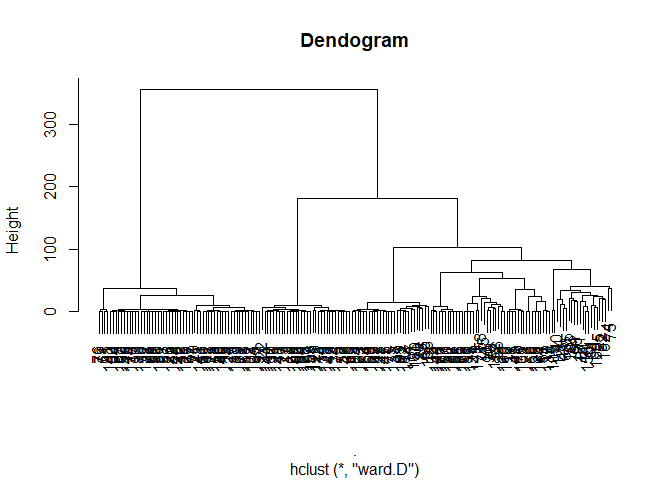

```r
dendogram %>%
  plot(main="Dendogram")
```

### Analyse clusters

#### Analyse variables by clusters

The idea is view how affect belonging to a cluster to the main variables distribution.

The main variables are those whose names do not begin with “something.”. So just keep columns whose name do not have ‘.’.

```r
cols_to_select <-
  df_clustering_info_added %>%
  colnames() %>%
  str_detect("\\.", negate = TRUE)
```

```r
means_by_cluster <-
  df_clustering_info_added %>%
  group_by(analysis_info.clustering.cluster.k10) %>%
  select_if(cols_to_select) %>%
  summarise_all(mean) %>%
  round(2) %>%
  rename_with(function(name) paste("mean", name, sep = "_")) %>%
  rename(cluster = mean_analysis_info.clustering.cluster.k10) %>%
  arrange(desc(mean_size))
means_by_cluster %>%
  paged_table()
```

| cluster | mean_size | mean_community_reputation | mean_harmless_votes | mean_malicious_votes | mean_positives | mean_times_submitted | mean_total | mean_total_PERMs | mean_unique_sources |
| --- | --- | --- | --- | --- | --- | --- | --- | --- | --- |
| 5 | 81435781 | 0.00 | 0 | 0.00 | 16.00 | 3.00 | 61.75 | 16.50 | 1.50 |
| 4 | 20694611 | 0.00 | 0 | 0.00 | 22.50 | 1.00 | 63.00 | 58.00 | 1.00 |
| 3 | 15169826 | 0.00 | 0 | 0.00 | 16.56 | 1.00 | 62.56 | 34.00 | 1.00 |
| 10 | 14498070 | 0.00 | 0 | 0.00 | 21.00 | 6.00 | 63.00 | 23.00 | 3.00 |
| 7 | 5446170 | 0.00 | 0 | 0.00 | 19.51 | 99.13 | 61.62 | 6.64 | 1.62 |
| 6 | 4283264 | -0.03 | 0 | 0.03 | 25.79 | 2.15 | 61.33 | 22.42 | 1.70 |
| 1 | 2668893 | 0.00 | 0 | 0.00 | 20.03 | 1.00 | 60.38 | 10.00 | 1.00 |
| 9 | 2481417 | -14.50 | 0 | 0.25 | 24.50 | 1.25 | 62.75 | 34.75 | 1.25 |
| 2 | 1052921 | 0.00 | 0 | 0.00 | 22.21 | 5.59 | 58.81 | 0.00 | 1.84 |
| 8 | 500276 | -34.00 | 18 | 13.00 | 26.00 | 263.00 | 64.00 | 4.00 | 514.00 |

#### Analyse variables by cluster size

The idea is view how affect the cluster size to the main variables distribution.

```r
means_by_cluster_size <-
  df_clustering_info_added %>%
  group_by(analysis_info.clustering.belongs_to_small_cluster.k10) %>%
  select_if(cols_to_select) %>%
  summarise_all(mean) %>%
  round(2) %>%
  rename_with(function(name) paste("mean", name, sep = "_")) %>%
  rename(small_cluster =
           mean_analysis_info.clustering.belongs_to_small_cluster.k10) %>%
  mutate(small_cluster = as.logical(small_cluster)) %>%
  arrange(desc(mean_size))
means_by_cluster_size %>%
  paged_table()
```

| small_cluster | mean_size | mean_community_reputation | mean_harmless_votes | mean_malicious_votes | mean_positives | mean_times_submitted | mean_total | mean_total_PERMs | mean_unique_sources |
| --- | --- | --- | --- | --- | --- | --- | --- | --- | --- |
| TRUE | 25170704 | -4.38 | 0.86 | 0.67 | 19.19 | 14.14 | 62.57 | 31.14 | 25.67 |
| FALSE | 3087792 | -0.01 | 0.00 | 0.01 | 21.86 | 26.50 | 60.31 | 8.14 | 1.59 |

The result is amazing! The risk of the virus increase so much by belonging to a small group.

Let’s express this in percentaje.

```r
increment_by_small_cluster <-
  (means_by_cluster_size[1,] /
  means_by_cluster_size[2,]) %>%
  select(-small_cluster)
increment_by_small_cluster %>%
  paged_table()
```

| mean_size | mean_community_reputation | mean_harmless_votes | mean_malicious_votes | mean_positives | mean_times_submitted | mean_total | mean_total_PERMs | mean_unique_sources |
| --- | --- | --- | --- | --- | --- | --- | --- | --- |
| 8.151683 | 438 | Inf | 67 | 0.8778591 | 0.5335849 | 1.037473 | 3.825553 | 16.14465 |

```r
increment_by_small_cluster_percentage <-
  (increment_by_small_cluster - 1) %>%
  select_if(function(x) !is.infinite(x)) %>%
  unlist() %>%
  percent()
increment_by_small_cluster_percentage
```

```
##                 mean_size mean_community_reputation      mean_malicious_votes
##                    "715%"                 "43 700%"                  "6 600%"
##            mean_positives      mean_times_submitted                mean_total
##                    "-12%"                    "-47%"                      "4%"
##          mean_total_PERMs       mean_unique_sources
##                    "283%"                  "1 514%"
```

## Summarize results.

Looking at the results of the dendogram and knowing the distribution of clusters, seem that most of the viruses follows common patterns, but there are some others that breaks radically with these patterns.

It is interesting to see how the most dangerous viruses:

- Are the only ones who have harmless votes.
- Request more permissions.

## Conclusion

Concluding, virus that don’t follow the commons patterns tends to be much more dangerous than the others.

## Save dataframe

Add the clustering information to the data frame.

```r
cluster_info_cols_index <-
  df_clustering_info_added %>%
  colnames() %>%
  str_detect("^analysis_info") %>%
  which()

cluster_info_cols <-
  df_clustering_info_added %>%
  select(all_of(cluster_info_cols_index))
```

```r
virusTotal_cluster <-
  virusTotal %>%
  select(-...1) %>%
  cbind(cluster_info_cols)
```

```r
write.csv(virusTotal_cluster, path_export)
```